# Climate-Smart Spatial Planning

```
#> [1] "klippy"
```

```r
print("library")
```

```
#> [1] "library"
```

```r
library(spatialplanr)
```

# Overview

This code has been written to simplify the process for running a *prioritizr* analysis on a given region. It is still a work in progress so feel free to submit pull requests with new features and code improvements.

## Set user parameters

You can set a region if it is defined in `splnr_get_planningUnits`.

```r
print("parameters")
```

```
#> [1] "parameters"
```

```r
Region <- "Coral Sea" # "Australia"
Type <- "Oceans" # "EEZ"
Shape <- "Hexagon" # "Shape of PUs
PU_size <- 10000 # km2

cCRS <- "+proj=moll +lon_0=0 +x_0=0 +y_0=0 +ellps=WGS84 +datum=WGS84 +units=m no_defs" # Mollweide
```

We can also use a customised `ggplot` theme that can be passed as a list to `splnr_gg_add()` and that can then be used for all plots. For example:

```r
splnr_theme <- list(
  ggplot2::theme_bw(),
  ggplot2::theme(
    legend.position = "right",
    legend.direction = "vertical",
    text = ggplot2::element_text(size = 9, colour = "black"),
    axis.text = ggplot2::element_text(size = 9, colour = "black"),
    plot.title = ggplot2::element_text(size = 9),
    axis.title = ggplot2::element_blank()
  )
)
```

## Analysis Region

Start your analysis by defining your region and setting up the planning units.

Get the boundary for your chosen region.

```r
Bndry <- splnr_get_boundary(Limits = Region, Type = Type, cCRS = cCRS)
landmass <- rnaturalearth::ne_countries(scale = "medium", returnclass = "sf") %>%
  sf::st_transform(cCRS)
```

## Create Planning Units

```r
PUs <- splnr_get_planningUnits(Bndry, landmass, PU_size, Shape)
```

## Get the features

For our example, we will use a small subset of charismatic megafauna species of the Coral Sea to inform the conservation plan. We filtered the Aquamaps (Aquamaps.org) species distribution models for our study area for the following species:

```r
Dict <- tibble::tribble(
  ~nameCommon, ~nameVariable, ~category,
  "Green sea turtle", "Chelonia_mydas", "Reptiles",
  "Loggerhead sea turtle", "Caretta_caretta", "Reptiles",
  "Hawksbill sea turtle", "Eretmochelys_imbricata", "Reptiles",
  "Olive ridley sea turtle", "Lepidochelys_olivacea", "Reptiles",
  "Saltwater crocodile", "Crocodylus_porosus", "Reptiles",
  "Humpback whale", "Megaptera_novaeangliae", "Mammals",
  "Common Minke whale", "Balaenoptera_acutorostrata",
  "Mammals",
  "Dugong", "Dugong_dugon", "Mammals",
  "Grey nurse shark", "Carcharias_taurus", "Sharks and rays",
  "Tiger shark", "Galeocerdo_cuvier", "Sharks and rays",
  "Great hammerhead shark", "Sphyrna_mokarran",
  "Sharks and rays",
  "Giant oceanic manta ray", "Mobula_birostris", "Sharks and rays",
  "Reef manta ray", "Mobula_alfredi", "Sharks and rays",
  "Whitetip reef shark", "Triaenodon_obesus", "Sharks and rays",
  "Red-footed booby", "Sula_sula", "Birds"
)
```

These species were not chosen based on their importance for this region and only represent an example for visualization purposes.

### Convert the probabilities to binary data

```r
datEx_species_bin <- spDataFiltered %>%
  dplyr::as_tibble() %>%
  dplyr::mutate(dplyr::across(
    -dplyr::any_of(c("cellID", "geometry")), # Don't apply to geometry/cellID
    ~ dplyr::case_when(
      . >= 0.5 ~ 1,
      . < 0.5 ~ 0,
      is.na(.data) ~ 0
    )
  )) %>%
  sf::st_as_sf()

col_name <- spDataFiltered %>%
  sf::st_drop_geometry() %>%
  dplyr::select(-"cellID") %>%
  colnames()
```

### Climate-smart spatial planning

So far, all steps were exactly the same as in a spatial plan that does not include climate change. To make the spatial plan climate smart, we need climate metrics.

```r
metric_df <- CoralSeaVelocity %>%
  dplyr::rename(metric = voccMag_transformed)
```

The climate velocity data can be visualized using the `splnr_plot_climData()` function.

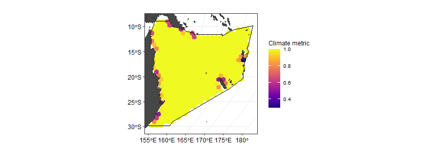

```r
(ggclim <- splnr_plot_climData(metric_df, "metric") +
  splnr_gg_add(
    Bndry = Bndry, overlay = landmass,
    cropOverlay = PUs, ggtheme = splnr_theme
  ))
```

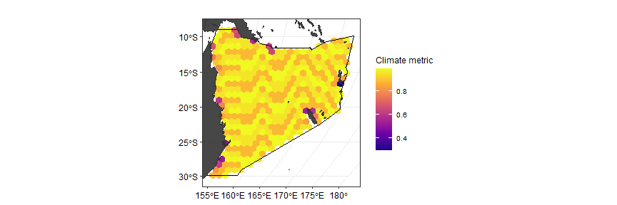

```r
set.seed(5)

metric_df <- CoralSeaVelocity %>%
  dplyr::rename(metric = voccMag_transformed) %>%
  dplyr::mutate(
    metricOG = metric,
    metric = ifelse(metric > 0.99, runif(., 0.85, 1.0), metric)
  )

(ggclim <- splnr_plot_climData(metric_df, "metric") +
  splnr_gg_add(
    Bndry = Bndry, overlay = landmass,
    cropOverlay = PUs, ggtheme = splnr_theme
  ))
```

We then use the climate priority area approach `splnr_climate_priorityAreaApproach()` detailed in [Buenafe et al (2023)](https://doi.org/10.1002/eap.2852) to determine climate refugia. Briefly, this approach selects a percentile (in our case 5%) of the suitable habitat of each feature that is considered the most climate-smart. It also requires a `direction` input indicating at which side of the metric range the more climate-smart areas can be found. In our case, lower climate velocity denotes more climate-smart (`direction = -1`), but in other cases a higher value might represent the more climate-smart planning units (`direction = 1`).

Using this approach also requires an adaptation of the targets, since 5% of the suitable habitat of each species is already protected in the climate-smart areas. We can decide how much of the 5% of the most climate-smart areas is supposed to be included in the spatial plan (here: `refugiaTarget = 1` to protect 100% of the 5% most climate-smart areas).

```r
target <- datEx_species_bin %>%
  sf::st_drop_geometry() %>%
  dplyr::select(-"cellID") %>%
  colnames() %>%
  data.frame() %>%
  setNames(c("feature")) %>%
  dplyr::mutate(target = 0.3)


CPA_Approach <- splnr_climate_priorityAreaApproach(
  featuresDF = datEx_species_bin,
  metricDF = metric_df, targetsDF = target, direction = -1, refugiaTarget = 1
)

out_sf <- CPA_Approach$Features %>%
  dplyr::left_join(
    datEx_species_bin %>%
      sf::st_drop_geometry() %>%
      dplyr::select(
        "cellID",
        tidyselect::starts_with("Cost_")
      ),
    by = "cellID"
  ) %>%
  dplyr::left_join(metric_df %>%
    sf::st_drop_geometry(), by = "cellID")

targets <- CPA_Approach$Targets
```

We now add other information required to perform the spatial planning, such as the cost, and extract the names of all used features.

```r
out_sf$Cost_None <- rep(1, 397)

usedFeatures <- out_sf %>%
  sf::st_drop_geometry() %>%
  dplyr::select(
    -tidyselect::starts_with("Cost_"),
    -"cellID",
    -tidyselect::starts_with("metric")
  ) %>%
  names()
```

### Run the climate-smart spatial planning

The `prioritizr`steps when including climate change are the same as when running a non-climate-smart spatial prioritization.

```r
p1 <- prioritizr::problem(out_sf, usedFeatures, "Cost_None") %>%
  prioritizr::add_min_set_objective() %>%
  prioritizr::add_relative_targets(targets$target) %>%
  prioritizr::add_binary_decisions() %>%
  prioritizr::add_default_solver(verbose = FALSE)

dat_solnClim <- prioritizr::solve.ConservationProblem(p1)
```

We can look at the resulting plan using `splnr_plot_solution()`.

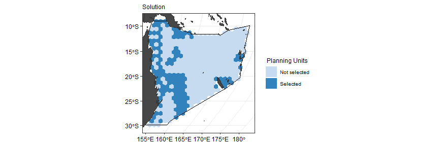

```r
(ggSoln <- splnr_plot_solution(dat_solnClim) +
  splnr_gg_add(
    Bndry = Bndry, overlay = landmass,
    cropOverlay = PUs, ggtheme = splnr_theme
  ))
```

However, we are also interested how climate-smart the selected planning units in the solution actually are. For this, we can use a kernel density plot

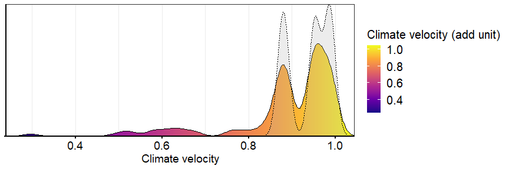

```r
(ggClimDens <- splnr_plot_climKernelDensity(
  soln = list(dat_solnClim),
  names = c("Input 1"), type = "Normal",
  legendTitle = "Climate velocity (add unit)",
  xAxisLab = "Climate velocity"
))
```

## Alternative Approaches

### Percentile Approach

```r
target <- datEx_species_bin %>%
  sf::st_drop_geometry() %>%
  dplyr::select(-"cellID") %>%
  colnames() %>%
  data.frame() %>%
  setNames(c("feature")) %>%
  dplyr::mutate(target = 30)

Percentile_Approach <- splnr_climate_percentileApproach(
  featuresDF = datEx_species_bin,
  metricDF = metric_df, targetsDF = target, direction = -1, percentile = 35
)
```

```
#> [1] "Lower values mean more climate-smart areas."
```

```r
out_sf <- Percentile_Approach$Features %>%
  dplyr::left_join(
    datEx_species_bin %>%
      sf::st_drop_geometry() %>%
      dplyr::select(
        "cellID",
        tidyselect::starts_with("Cost_")
      ),
    by = "cellID"
  ) %>%
  dplyr::left_join(metric_df %>%
    sf::st_drop_geometry(), by = "cellID")

targets <- Percentile_Approach$Targets
```

We now add other information required to perform the spatial planning, such as the cost, and extract the names of all used features to then run a prioritisation.

```r
out_sf$Cost_None <- rep(1, 397)

usedFeatures <- out_sf %>%
  sf::st_drop_geometry() %>%
  dplyr::select(
    -tidyselect::starts_with("Cost_"),
    -"cellID",
    -tidyselect::starts_with("metric")
  ) %>%
  names()

p2 <- prioritizr::problem(out_sf, usedFeatures, "Cost_None") %>%
  prioritizr::add_min_set_objective() %>%
  prioritizr::add_relative_targets(targets$target) %>%
  prioritizr::add_binary_decisions() %>%
  prioritizr::add_default_solver(verbose = FALSE)

dat_solnClimPercentile <- prioritizr::solve.ConservationProblem(p2,
  force = TRUE
)
```

We can look at the resulting plan using `splnr_plot_solution()`.

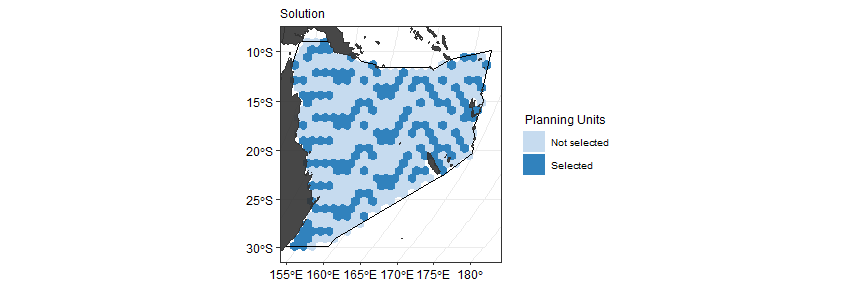

```r
(ggSoln <- splnr_plot_solution(dat_solnClimPercentile) +
  splnr_gg_add(
    Bndry = Bndry, overlay = landmass,
    cropOverlay = PUs, ggtheme = splnr_theme
  ))
```

However, we are also interested how climate-smart the selected planning units in the solution actually are. For this, we can use a kernel density plot

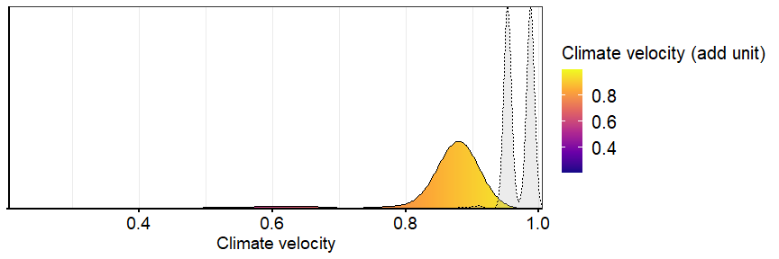

```r
(ggClimDens <- splnr_plot_climKernelDensity(
  soln = list(dat_solnClimPercentile),
  names = c("Input 1"), type = "Normal",
  legendTitle = "Climate velocity (add unit)",
  xAxisLab = "Climate velocity"
))
```

### Feature Approach

```r
target <- datEx_species_bin %>%
  sf::st_drop_geometry() %>%
  dplyr::select(-"cellID") %>%
  colnames() %>%
  data.frame() %>%
  setNames(c("feature")) %>%
  dplyr::mutate(target = 0.3)

Feature_Approach <- splnr_climate_featureApproach(
  featuresDF = datEx_species_bin,
  metricDF = metric_df, targetsDF = target, direction = 1
)
```

```
#> [1] "Higher values mean more climate-smart areas."
```

```r
out_sf <- Feature_Approach$Features %>%
  dplyr::left_join(
    datEx_species_bin %>%
      sf::st_drop_geometry() %>%
      dplyr::select(
        "cellID",
        tidyselect::starts_with("Cost_")
      ),
    by = "cellID"
  ) %>%
  dplyr::left_join(metric_df %>%
    sf::st_drop_geometry(), by = "cellID")

targets <- Feature_Approach$Targets
```

We now add other information required to perform the spatial planning, such as the cost, and extract the names of all used features to then run a prioritisation.

```r
out_sf$Cost_None <- rep(1, 397)

usedFeatures <- out_sf %>%
  sf::st_drop_geometry() %>%
  dplyr::select(
    -tidyselect::starts_with("Cost_"),
    -"cellID",
    -tidyselect::starts_with("metric")
  ) %>%
  names()

p3 <- prioritizr::problem(out_sf, usedFeatures, "Cost_None") %>%
  prioritizr::add_min_set_objective() %>%
  prioritizr::add_relative_targets(targets$target) %>%
  prioritizr::add_binary_decisions() %>%
  prioritizr::add_default_solver(verbose = FALSE)

dat_solnClimFeature <- prioritizr::solve.ConservationProblem(p3)
```

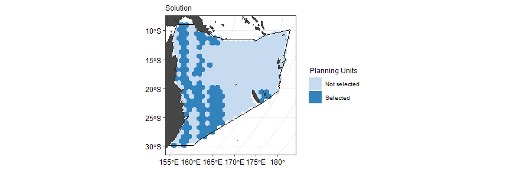

```r
(ggSoln <- splnr_plot_solution(dat_solnClimFeature) +
  splnr_gg_add(
    Bndry = Bndry, overlay = landmass,
    cropOverlay = PUs, ggtheme = splnr_theme
  ))
```

However, we are also interested how climate-smart the selected planning units in the solution actually are. For this, we can use a kernel density plot

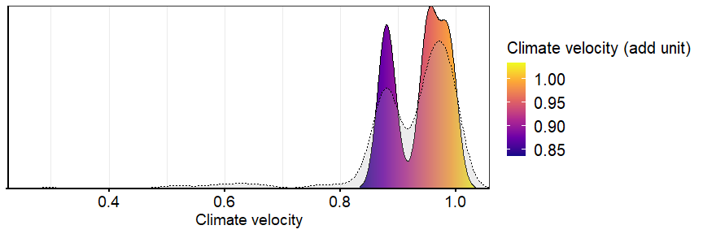

```r
(ggClimDens <- splnr_plot_climKernelDensity(
  soln = list(dat_solnClimFeature),
  names = c("Input 1"), type = "Normal",
  legendTitle = "Climate velocity (add unit)",
  xAxisLab = "Climate velocity"
))
```